# Caso_practico_Josue

## Desarrollo Caso Práctico Evaluación Final

**Tareas que nos pide la empresa:**

- Realización de un análisis de las variables del dataset de Google Analytics como pueden ser histogramas, boxplots, etc. Cualquier otro análisis es bienvenido, siempre explicándolo y con un sentido de negocio.
- Tratamiento de los valores faltantes, outliers, etc., en caso de que los hubiese. Si hay valores con missings, habrá que eliminarlos con el método de Pandas llamado Dropna().a.
- Tratamiento de categóricas, pasándolas a numéricas por medio de dummies, mapeándolas o utilizando un label encoder. Hay que justificar las operaciones que se realizan.
- Si existe alguna variable que se necesite borrar, habrá que borrara y justificarlo.
- Estandariza los datos.
- Dividir los datos en train y en test. Con los datos de train se pretende ajustar modelos con CrossValidation y GridSearch.
- Utilizar un modelo lineal. Entre los modelos lineales están las regresiones logísticas, las regresiones lineales, etc.
- Utilizar un modelo de redes neuronales.
- Utilizar cualquier otro modelo de clasificación.
- Optimizar algún parámetro de cada modelo utilizando CrossValidation y GridSearch, o de la forma que se estime oportuna, siempre justificándolo.
- Elegir el mejor modelo de los tres según la métrica ROC en CrossValidation. Predecir Test y obtener una métrica estimada.
- Umbralizar las probabilidades utilizando el umbral que maximice el área bajo la curva ROC.

### Carga de Librerías

```python
import numpy as np
import matplotlib.pyplot as plt
import pandas as pd
import seaborn as sns
from sklearn.model_selection import train_test_split
from sklearn.preprocessing import StandardScaler
from sklearn.model_selection import GridSearchCV
from sklearn.linear_model import LogisticRegression
from sklearn.neural_network import MLPClassifier
import sklearn.metrics as metrics
import xgboost as xgb
```

### Definición de Funciones

```python
def box_plot(X):
    "Esta función crea distintos gráficos box_plot para cada variable del conjunto X"
    plt.figure(figsize=(16,8))
    ax = sns.boxplot(data=X)
    ticks = range(len(ax.get_xticklabels()))
    ax.set_xticks(ticks)
    ax.set_xticklabels(ax.get_xticklabels(), rotation=90)
    plt.title(u'Representación de cajas de las variables independientes X')
    plt.ylabel('Valor de la variable normalizada')
    _ = plt.xlabel('Nombre de la variable')

def creacion_histo(X):
    "Esta función crea distintos histogramas para cada variable del conjunto X"
    plt.figure(figsize=(18,20))
    n = 0
    for i, column in enumerate(X.columns):
        n+=1
        plt.subplot(5, 4, n)
        sns.histplot(X[column], kde=True, bins=30)
        plt.title('Distribución {}'.format(column))
    plt.tight_layout()
    plt.show()

def relaciones_vs_target(X, Y, return_type='axes'):
    "Esta función muestra la relación entre las variables dependientes y la variable objetivo"
    fig_tot = (len(X.columns))
    fig_por_fila = 4
    tamanio_fig = 5
    num_filas = int( np.ceil(fig_tot/fig_por_fila) )
    plt.figure( figsize=( fig_por_fila*tamanio_fig+5, num_filas*tamanio_fig+5 ) )
    c = 0
    for i, col in enumerate(X.columns):
        plt.subplot(num_filas, fig_por_fila, i+1)
        sns.scatterplot(x=X[col], y=Y)
        plt.title( '%s vs %s' % (col, 'target') )
        plt.ylabel('Target')
        plt.xlabel(col)
    plt.show()

def doble_hist(x_1, x_0, n_bins=11, title='', label_1='Clase 1',
                          label_0='Clase 0', density=0):
    "Esta función recibe dos distribuciones de probabilidad y las presenta gráficamente"
    bins = n_bins
    plt.hist(x_1, bins, density = density, alpha=0.5, label=label_1, color='red')
    plt.hist(x_0, bins, density = density, alpha=0.5, label=label_0, color='green')
    plt.title(title)
    plt.legend(loc='best')

def hist_pos_neg_feat(x, y, density=0, nbins=11, targets=(0,1)):
    "Presenta los valores de las variables independientes distribuidas y separadas de acuerdo a la variable objetivo"
    fig_tot = len(x.columns)
    fig_tot_fila = 4; fig_tamanio = 4
    num_filas = int( np.ceil(fig_tot/fig_tot_fila) )
    plt.figure( figsize=( fig_tot_fila*fig_tamanio+2, num_filas*fig_tamanio+2 ) )
    target_neg, target_pos = targets
    for i, feat in enumerate(x.columns):
        plt.subplot(num_filas, fig_tot_fila, i+1);
        plt.title('%s' % feat)
        idx_pos = y == target_pos
        idx_neg= y == target_neg
        doble_hist(x[feat][idx_pos].values, x[feat][idx_neg].values, nbins,
                   density = density, title=('%s' % feat))
```

### Carga de Datos

```python
XY = pd.read_csv('./online_shoppers_intention.csv', sep=',', index_col=False)
```

```python
#Visualizamos la estructura de las primeras 5 filas
XY.head()
```

|  | Administrative | Administrative_Duration | Informational | Informational_Duration | ProductRelated | ProductRelated_Duration | BounceRates | ExitRates | PageValues | SpecialDay | Month | OperatingSystems | Browser | Region | TrafficType | VisitorType | Weekend | Revenue |
| --- | --- | --- | --- | --- | --- | --- | --- | --- | --- | --- | --- | --- | --- | --- | --- | --- | --- | --- |
| 0 | 0.0 | 0.0 | 0.0 | 0.0 | 1.0 | 0.000000 | 0.20 | 0.20 | 0.0 | 0.0 | Feb | 1 | 1 | 1 | 1 | Returning_Visitor | False | False |
| 1 | 0.0 | 0.0 | 0.0 | 0.0 | 2.0 | 64.000000 | 0.00 | 0.10 | 0.0 | 0.0 | Feb | 2 | 2 | 1 | 2 | Returning_Visitor | False | False |
| 2 | 0.0 | -1.0 | 0.0 | -1.0 | 1.0 | -1.000000 | 0.20 | 0.20 | 0.0 | 0.0 | Feb | 4 | 1 | 9 | 3 | Returning_Visitor | False | False |
| 3 | 0.0 | 0.0 | 0.0 | 0.0 | 2.0 | 2.666667 | 0.05 | 0.14 | 0.0 | 0.0 | Feb | 3 | 2 | 2 | 4 | Returning_Visitor | False | False |
| 4 | 0.0 | 0.0 | 0.0 | 0.0 | 10.0 | 627.500000 | 0.02 | 0.05 | 0.0 | 0.0 | Feb | 3 | 3 | 1 | 4 | Returning_Visitor | True | False |

```python
#Imprimimos información general del dataset
print(u'- El número de filas en el dataset es: {}'.format(XY.shape[0]))
print(u'- El número de columnas en el dataset es: {}'.format(XY.shape[1]))
print(u'- El número de variables numéricas en el dataset es: {}'.format(len(XY.select_dtypes(include='number').columns)))
print(u'- El número de variables no numéricas en el dataset es: {}'.format(len(XY.select_dtypes(exclude='number').columns)))
print(u'- Los nombres de las variables independientes son: {}'.format(list(XY.columns)))
```

```
- El número de filas en el dataset es: 12330
- El número de columnas en el dataset es: 18
- El número de variables numéricas en el dataset es: 14
- El número de variables no numéricas en el dataset es: 4
- Los nombres de las variables independientes son: ['Administrative', 'Administrative_Duration', 'Informational', 'Informational_Duration', 'ProductRelated', 'ProductRelated_Duration', 'BounceRates', 'ExitRates', 'PageValues', 'SpecialDay', 'Month', 'OperatingSystems', 'Browser', 'Region', 'TrafficT…
```

```python
#Consultamos la existencia de valores faltantes
XY.isnull().sum()
```

```
Administrative             14
Administrative_Duration    14
Informational              14
Informational_Duration     14
ProductRelated             14
ProductRelated_Duration    14
BounceRates                14
ExitRates                  14
PageValues                  0
SpecialDay                  0
Month                       0
OperatingSystems            0
Browser                     0
Region                      0
TrafficType                 0
VisitorType                 0
Weekend                     0
Revenue                     0
dtype: int64
```

```python
# Observamos las filas con valores nulos
XY_nulos = XY[XY.isnull().any(axis=1)]
XY_nulos
```

|  | Administrative | Administrative_Duration | Informational | Informational_Duration | ProductRelated | ProductRelated_Duration | BounceRates | ExitRates | PageValues | SpecialDay | Month | OperatingSystems | Browser | Region | TrafficType | VisitorType | Weekend | Revenue |
| --- | --- | --- | --- | --- | --- | --- | --- | --- | --- | --- | --- | --- | --- | --- | --- | --- | --- | --- |
| 1065 | NaN | NaN | NaN | NaN | NaN | NaN | NaN | NaN | 0.0 | 0.0 | Mar | 2 | 2 | 2 | 1 | Returning_Visitor | False | False |
| 1132 | NaN | NaN | NaN | NaN | NaN | NaN | NaN | NaN | 0.0 | 0.0 | Mar | 1 | 1 | 1 | 2 | Returning_Visitor | False | False |
| 1133 | NaN | NaN | NaN | NaN | NaN | NaN | NaN | NaN | 0.0 | 0.0 | Mar | 2 | 4 | 5 | 1 | Returning_Visitor | False | False |
| 1134 | NaN | NaN | NaN | NaN | NaN | NaN | NaN | NaN | 0.0 | 0.0 | Mar | 2 | 2 | 1 | 2 | Returning_Visitor | False | False |
| 1135 | NaN | NaN | NaN | NaN | NaN | NaN | NaN | NaN | 0.0 | 0.0 | Mar | 3 | 2 | 1 | 1 | Returning_Visitor | False | False |
| 1136 | NaN | NaN | NaN | NaN | NaN | NaN | NaN | NaN | 0.0 | 0.0 | Mar | 2 | 2 | 1 | 2 | Returning_Visitor | False | False |
| 1473 | NaN | NaN | NaN | NaN | NaN | NaN | NaN | NaN | 0.0 | 0.0 | Mar | 2 | 2 | 1 | 1 | Returning_Visitor | True | False |
| 1474 | NaN | NaN | NaN | NaN | NaN | NaN | NaN | NaN | 0.0 | 0.0 | Mar | 1 | 1 | 6 | 1 | Returning_Visitor | True | False |
| 1475 | NaN | NaN | NaN | NaN | NaN | NaN | NaN | NaN | 0.0 | 0.0 | Mar | 2 | 2 | 3 | 1 | Returning_Visitor | False | False |
| 1476 | NaN | NaN | NaN | NaN | NaN | NaN | NaN | NaN | 0.0 | 0.0 | Mar | 1 | 1 | 2 | 3 | Returning_Visitor | False | False |
| 2037 | NaN | NaN | NaN | NaN | NaN | NaN | NaN | NaN | 0.0 | 0.0 | Mar | 3 | 2 | 4 | 1 | Returning_Visitor | False | False |
| 2038 | NaN | NaN | NaN | NaN | NaN | NaN | NaN | NaN | 0.0 | 0.0 | Mar | 2 | 2 | 1 | 2 | Returning_Visitor | False | False |
| 2039 | NaN | NaN | NaN | NaN | NaN | NaN | NaN | NaN | 0.0 | 0.0 | Mar | 3 | 2 | 4 | 15 | Returning_Visitor | True | False |
| 2753 | NaN | NaN | NaN | NaN | NaN | NaN | NaN | NaN | 0.0 | 0.0 | May | 2 | 2 | 4 | 13 | Returning_Visitor | False | False |

```python
# Tal y como se indica en las instrucciones, se eliminan los valores nulos
XY = XY.dropna()
```

```python
# Para comprender más los datos revisamos su información y estadísticas generales
XY.info()
```

```
<class 'pandas.core.frame.DataFrame'>
Index: 12316 entries, 0 to 12329
Data columns (total 18 columns):
 #   Column                   Non-Null Count  Dtype
---  ------                   --------------  -----
 0   Administrative           12316 non-null  float64
 1   Administrative_Duration  12316 non-null  float64
 2   Informational            12316 non-null  float64
 3   Informational_Duration   12316 non-null  float64
 4   ProductRelated           12316 non-null  float64
 5   ProductRelated_Duration  12316 non-null  float64
 6   BounceRates              12316 non-null  float64
 7   ExitRates                12316 non-null  float64
 8   PageValues               12316 non-null  float64
 9   SpecialDay               12316 non-null  float64
 10  Month                    12316 non-null  object
 11  OperatingSystems         12316 non-null  int64
 12  Browser                  12316 non-null  int64
 13  Region                   12316 non-null  int64
 14  TrafficType              12316 non-null  int64
 15  VisitorType              12316 non-null  object
 16  Weekend                  12316 non-null  bool
 17  Revenue                  12316 non-null  bool
dtypes: bool(2), float64(10), int64(4), object(2)
memory usage: 1.6+ MB
```

```python
XY.describe()
```

|  | Administrative | Administrative_Duration | Informational | Informational_Duration | ProductRelated | ProductRelated_Duration | BounceRates | ExitRates | PageValues | SpecialDay | OperatingSystems | Browser | Region | TrafficType |
| --- | --- | --- | --- | --- | --- | --- | --- | --- | --- | --- | --- | --- | --- | --- |
| count | 12316.000000 | 12316.000000 | 12316.000000 | 12316.000000 | 12316.000000 | 12316.000000 | 12316.000000 | 12316.000000 | 12316.000000 | 12316.000000 | 12316.000000 | 12316.000000 | 12316.000000 | 12316.000000 |
| mean | 2.317798 | 80.906176 | 0.503979 | 34.506387 | 31.763884 | 1196.037057 | 0.022152 | 0.043003 | 5.895952 | 0.061497 | 2.124147 | 2.357584 | 3.148019 | 4.070477 |
| std | 3.322754 | 176.860432 | 1.270701 | 140.825479 | 44.490339 | 1914.372511 | 0.048427 | 0.048527 | 18.577926 | 0.199020 | 0.911566 | 1.718028 | 2.402211 | 4.024598 |
| min | 0.000000 | -1.000000 | 0.000000 | -1.000000 | 0.000000 | -1.000000 | 0.000000 | 0.000000 | 0.000000 | 0.000000 | 1.000000 | 1.000000 | 1.000000 | 1.000000 |
| 25% | 0.000000 | 0.000000 | 0.000000 | 0.000000 | 7.000000 | 185.000000 | 0.000000 | 0.014286 | 0.000000 | 0.000000 | 2.000000 | 2.000000 | 1.000000 | 2.000000 |
| 50% | 1.000000 | 8.000000 | 0.000000 | 0.000000 | 18.000000 | 599.766190 | 0.003119 | 0.025124 | 0.000000 | 0.000000 | 2.000000 | 2.000000 | 3.000000 | 2.000000 |
| 75% | 4.000000 | 93.500000 | 0.000000 | 0.000000 | 38.000000 | 1466.479902 | 0.016684 | 0.050000 | 0.000000 | 0.000000 | 3.000000 | 2.000000 | 4.000000 | 4.000000 |
| max | 27.000000 | 3398.750000 | 24.000000 | 2549.375000 | 705.000000 | 63973.522230 | 0.200000 | 0.200000 | 361.763742 | 1.000000 | 8.000000 | 13.000000 | 9.000000 | 20.000000 |

```python
XY.describe(include=object)
```

|  | Month | VisitorType |
| --- | --- | --- |
| count | 12316 | 12316 |
| unique | 10 | 3 |
| top | May | Returning_Visitor |
| freq | 3363 | 10537 |

Ya habiendo limpiado el dataset de valores nulos, observamos que las columnas **'Weekend'** y **'Revenue'** son booleanas, por lo que las cambiaremos para que presenten valores de 0 y 1, False = 0 y True = 1

```python
XY[['Revenue', 'Weekend']] = XY[['Revenue', 'Weekend']].applymap({False : 0, True : 1}.get)
```

```python
XY[:2]
```

|  | Administrative | Administrative_Duration | Informational | Informational_Duration | ProductRelated | ProductRelated_Duration | BounceRates | ExitRates | PageValues | SpecialDay | Month | OperatingSystems | Browser | Region | TrafficType | VisitorType | Weekend | Revenue |
| --- | --- | --- | --- | --- | --- | --- | --- | --- | --- | --- | --- | --- | --- | --- | --- | --- | --- | --- |
| 0 | 0.0 | 0.0 | 0.0 | 0.0 | 1.0 | 0.0 | 0.2 | 0.2 | 0.0 | 0.0 | Feb | 1 | 1 | 1 | 1 | Returning_Visitor | 0 | 0 |
| 1 | 0.0 | 0.0 | 0.0 | 0.0 | 2.0 | 64.0 | 0.0 | 0.1 | 0.0 | 0.0 | Feb | 2 | 2 | 1 | 2 | Returning_Visitor | 0 | 0 |

```python
XY.Revenue.value_counts()
```

```
Revenue
0    10408
1     1908
Name: count, dtype: int64
```

Ahora procederemos a revisar las variables categorícas para darles el tratamiento correspondiente

```python
#Primeramente la variable Month
Cantidad_mes = pd.DataFrame()
Cantidad_mes['Cantidad'] = XY.Month.value_counts()
Cantidad_mes['Porcentaje'] = Cantidad_mes['Cantidad']/len(XY)*100
Cantidad_mes
```

| Month | Cantidad | Porcentaje |
| --- | --- | --- |
| May | 3363 | 27.305943 |
| Nov | 2998 | 24.342319 |
| Mar | 1894 | 15.378370 |
| Dec | 1727 | 14.022410 |
| Oct | 549 | 4.457616 |
| Sep | 448 | 3.637545 |
| Aug | 433 | 3.515752 |
| Jul | 432 | 3.507632 |
| June | 288 | 2.338422 |
| Feb | 184 | 1.493992 |

Un aspecto interesante es que alrededor del 80% de los datos corresponden a los meses de mayo, noviembre, marzo y diciembre

```python
print(f'Porcentaje de Registros de los principales 4 meses: {round(Cantidad_mes.Porcentaje.iloc[:4].sum(),2)}')
```

```
Porcentaje de Registros de los principales 4 meses: 81.05
```

Para este caso, en aras de conservar el orden de los meses haremos un mapeo manual

```python
orden = {'Feb' : 0, 'Mar' : 1, 'May' : 2, 'June' : 3, 'Jul' : 4,
         'Aug' : 5, 'Sep' : 6, 'Oct' : 7, 'Nov' : 8, 'Dec' : 9}
XY['Month'].replace(orden, inplace=True)
```

```python
#Ahora veremos la variable Visitor_Type
XY.VisitorType.value_counts()
```

```
VisitorType
Returning_Visitor    10537
New_Visitor           1694
Other                   85
Name: count, dtype: int64
```

En este caso, considerando que el tipo Returning_Visitor es considerablemente representativo, haremos también un mapeo manual, dejando en 1 si corresponde a Returning_Visitor y 0 en caso contrario

```python
XY.loc[XY.VisitorType != 'Returning_Visitor', 'VisitorType'] = 0
XY.loc[XY.VisitorType == 'Returning_Visitor', 'VisitorType'] = 1
XY.VisitorType = XY.VisitorType.astype('Int64')
```

## Análisis de los Datos

Habiendo depurado la data, procedemos a realizar análisis a través de distintas visualizaciones. Primeramente separamos los datos:

```python
X = XY.drop('Revenue', axis=1)
Y = XY['Revenue']
```

```python
#Normalizamos X para ver la distribución de los datos e identificar posibles outliers
X_normalizado = (X-X.mean())/X.std()
```

```python
X[:2]
```

|  | Administrative | Administrative_Duration | Informational | Informational_Duration | ProductRelated | ProductRelated_Duration | BounceRates | ExitRates | PageValues | SpecialDay | Month | OperatingSystems | Browser | Region | TrafficType | VisitorType | Weekend |
| --- | --- | --- | --- | --- | --- | --- | --- | --- | --- | --- | --- | --- | --- | --- | --- | --- | --- |
| 0 | 0.0 | 0.0 | 0.0 | 0.0 | 1.0 | 0.0 | 0.2 | 0.2 | 0.0 | 0.0 | 0 | 1 | 1 | 1 | 1 | 1 | 0 |
| 1 | 0.0 | 0.0 | 0.0 | 0.0 | 2.0 | 64.0 | 0.0 | 0.1 | 0.0 | 0.0 | 0 | 2 | 2 | 1 | 2 | 1 | 0 |

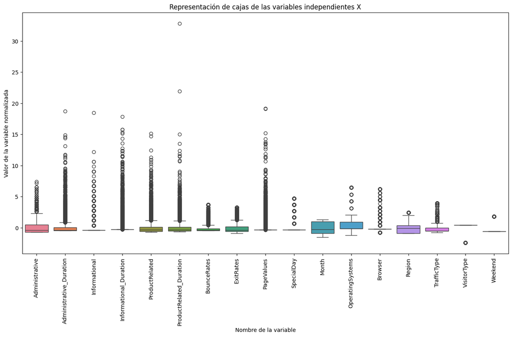

```python
#Creamos un boxplot
box_plot(X_normalizado)
```

Por lo visto en el gráfico anterior casi todas las variables tienen outliers, por lo que más adelante trabajaremos en ellos. Ahora visualizaremos las distribución de densidad de cada variable

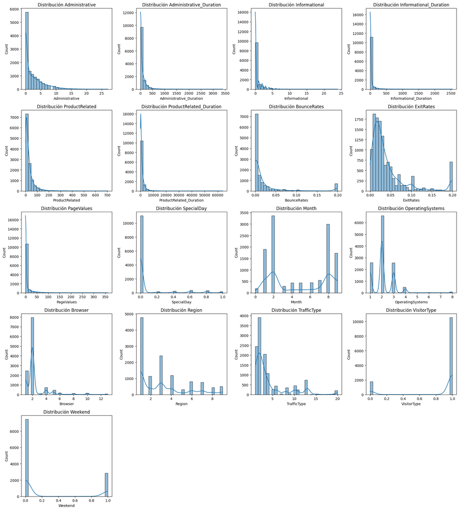

```python
creacion_histo(X)
```

Cómo se observa en el gráfico, las variables no siguen distribuciones normales. Ahora veremos la relación de las variables independiente con nuestra variable objetivo:

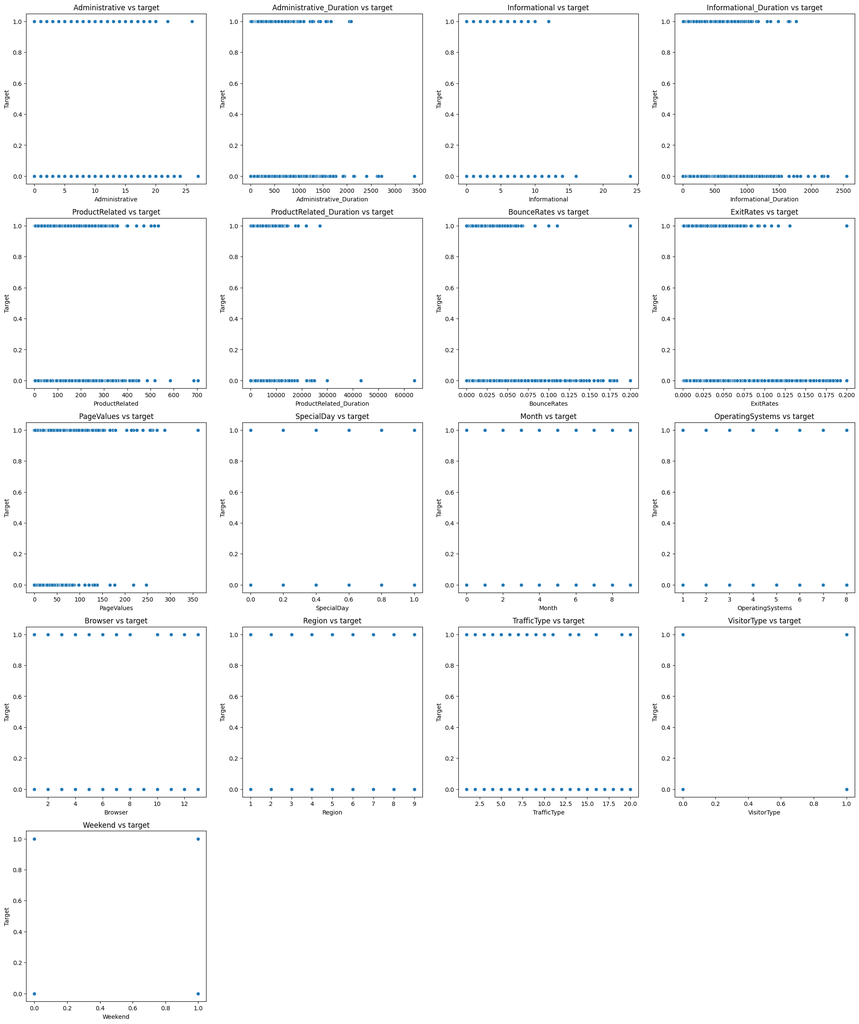

```python
# Creamos distintos scatterplots para visualizar posibles relaciones
relaciones_vs_target(X, Y)
```

No se visulizan realaciones claras en lo gráficos anteriores. Ahora generaremos distintos gráficos de barras que separen nuestra variable objetivo de acuerdo al valor de las variables independientes:

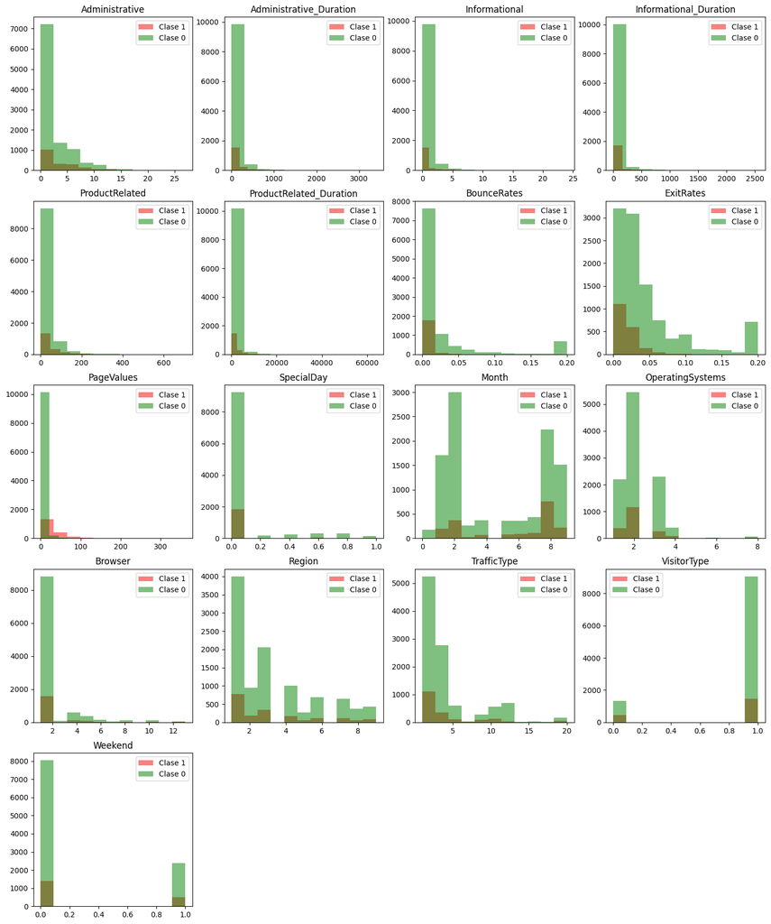

```python
hist_pos_neg_feat(X,Y)
```

No se logra identificar una variable que separe de forma significativa la variable objetivo. La Variable **"PageValue"** ligeramente muestra que a mayor sea su valor, es más probable que se genere una venta. Continuamos con la evaluación del poder predictivo de las variables, ahora generando la matriz de correlación:

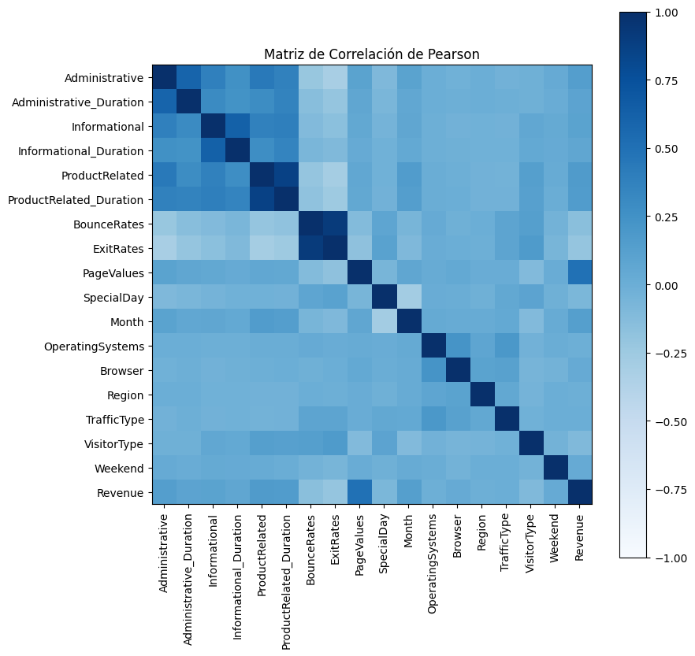

```python
#Generamos la matriz de correlaciones de Pearson
matriz_correlaciones = XY.corr(method='pearson')
n_ticks = len(XY.columns)
plt.figure( figsize=(9, 9) )
plt.xticks(range(n_ticks), XY.columns, rotation='vertical')
plt.yticks(range(n_ticks), XY.columns)
plt.colorbar(plt.imshow(matriz_correlaciones, interpolation='nearest',
                            vmin=-1., vmax=1.,
                            cmap=plt.get_cmap('Blues')))
_ = plt.title('Matriz de Correlación de Pearson')
```

De esta visualización más información significativa:

- Se visualiza que en efecto la variable **"PageValues"** tiene una alta correlación respecto al target en comparación a las demás variables
- También vemos como variables como el **"Browser"**, el **"OperatingSystems"** y la **"Region"** poco indicen en la materialización del ingreso

Ahora generamos una tabla con las variables que presentan mayor correlación con la variable objetivo y posteriormente eliminaremos las que aporte menos de 0,05 al comportamiento de la variable objetivo

```python
#Tabla de Correlaciones ordenadas por valor absoluto
correlaciones_target = matriz_correlaciones.values[ -1, : -1]
indices_inversos =  abs(correlaciones_target[ : ]).argsort()[ : : -1]
diccionario = {}
for nombre, correlacion in zip( X.columns[indices_inversos], list(correlaciones_target[indices_inversos] ) ):
    diccionario[nombre] = correlacion
correlaciones = pd.DataFrame.from_dict(diccionario, orient='index', columns=['Correlacion_con_Revenue'])
correlaciones
```

|  | Correlacion_con_Revenue |
| --- | --- |
| PageValues | 0.492494 |
| ExitRates | -0.206886 |
| ProductRelated | 0.158280 |
| ProductRelated_Duration | 0.152130 |
| BounceRates | -0.150621 |
| Administrative | 0.138631 |
| Month | 0.126797 |
| VisitorType | -0.103664 |
| Informational | 0.095085 |
| Administrative_Duration | 0.093395 |
| SpecialDay | -0.082468 |
| Informational_Duration | 0.070250 |
| Weekend | 0.029293 |
| Browser | 0.023869 |
| OperatingSystems | -0.014740 |
| Region | -0.011717 |
| TrafficType | -0.005212 |

```python
# Eliminamos las variables poco representativas
variables = correlaciones.loc[abs(correlaciones.Correlacion_con_Revenue) <= 0.05].index.tolist()
X_depurado = X.drop(columns=variables, axis=1)
```

```python
X_depurado[:2]
```

|  | Administrative | Administrative_Duration | Informational | Informational_Duration | ProductRelated | ProductRelated_Duration | BounceRates | ExitRates | PageValues | SpecialDay | Month | VisitorType |
| --- | --- | --- | --- | --- | --- | --- | --- | --- | --- | --- | --- | --- |
| 0 | 0.0 | 0.0 | 0.0 | 0.0 | 1.0 | 0.0 | 0.2 | 0.2 | 0.0 | 0.0 | 0 | 1 |
| 1 | 0.0 | 0.0 | 0.0 | 0.0 | 2.0 | 64.0 | 0.0 | 0.1 | 0.0 | 0.0 | 0 | 1 |

## Escalado y Tratamiento de outliers

```python
#Escalamos los datos
escalado = StandardScaler()
X_escalado = escalado.fit_transform(X_depurado)
X_escalado = pd.DataFrame(X_escalado, columns=X_depurado.columns)
```

Como vimos en una visualización anterior, el dataset presenta outliers que, por los algoritmos que vamos a utilizar, pueden afectar el modelo que se desarrollará

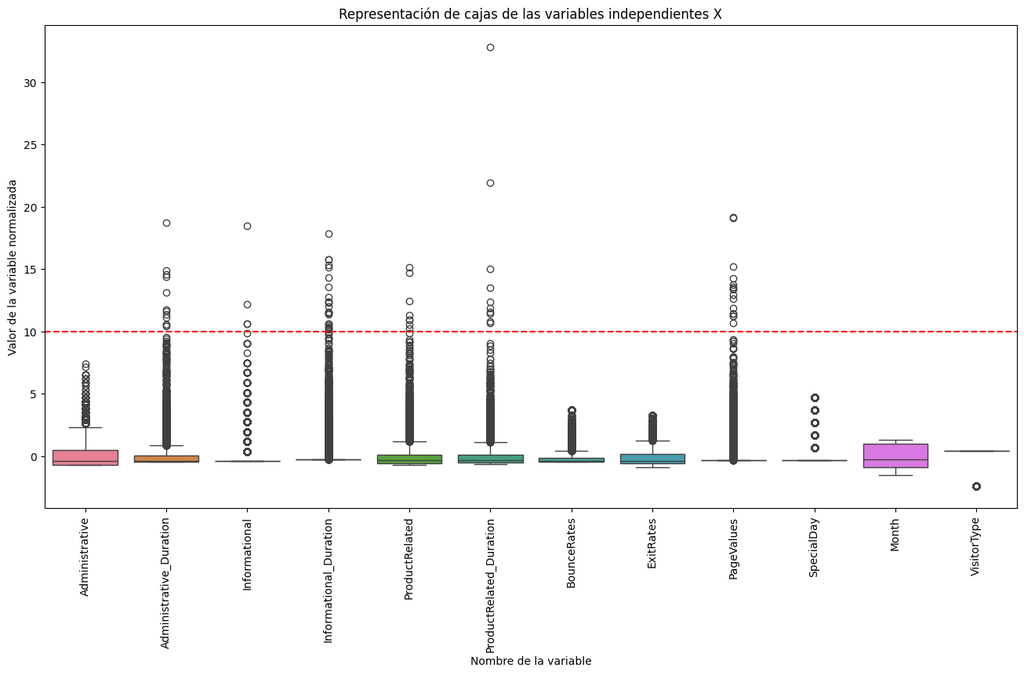

```python
# Visualizamos los datos nuevamente en boxplot, pero estableciendo un límite para los outliers igual a 10
plt.figure(figsize=(16,8))
ax = sns.boxplot(data=X_escalado)
ticks = range(len(ax.get_xticklabels()))
ax.set_xticks(ticks)
ax.set_xticklabels(ax.get_xticklabels(), rotation=90)
ax.axhline(y=10, color='r', linestyle='--')
plt.title(u'Representación de cajas de las variables independientes X')
plt.ylabel('Valor de la variable normalizada')
_ = plt.xlabel('Nombre de la variable')
```

Esta decisión se toma porque si eliminamos todos los outliers indicados por la gráfica, dejaríamos algunas variables con un único valor, como es el caso de PageValues, la cual presenta un alto valor de correlación respecto a la variable objetivo

En este caso ajustaremos los datos para que se mantengan por debajo del límite superior igual a 10

```python
for k in list(X_escalado.columns):
    IQR = np.percentile(X_escalado[k],75) - np.percentile(X_escalado[k],25)

    limite_superior = 10

    X_escalado[k] = np.where(X_escalado[k] > limite_superior,limite_superior,X_escalado[k])
```

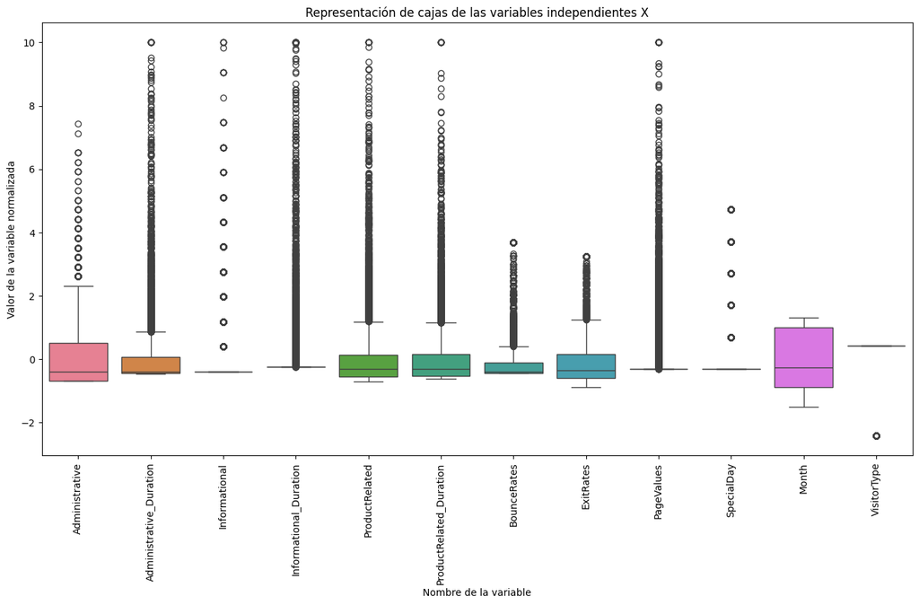

```python
box_plot(X_escalado)
```

Habiendo definido como manejaremos los outliers, procedemos a separar la data en train y test:

```python
#Separación del Dataset
X_train, X_test, Y_train, Y_test = train_test_split(X_escalado, Y, test_size=0.2, random_state=0)
```

## Entrenamiento de modelos

De acuerdo a las indicaciones del caso, se procederá a desarrollar 3 modelos, una **Regresión Logística**, por ser un problema de clasificación, una **Red Neuronal** tradicional y y el tercero, al ser de selección libre, se utilizará el algoritmo de **XGBoost**

**Regresión Logística**

```python
#Primeramente definimos el modelo y utilizaremos GridSearchCV para optimizar C y class_weight para manejar el desequilibrio
#Posterior generamos el entrenamiento para obtener los mejores hiperparámetros
modelo_LR = LogisticRegression()
parametros_LR = {"C": [0.01, 0.02, 0.03, 0.04, 0.05, 0.06, 0.07, 0.08,0.09],
              "class_weight":['balanced', None]}
modelo_LR_gs = GridSearchCV(modelo_LR, param_grid=parametros_LR,
                         cv = 5, scoring='roc_auc')
modelo_LR_gs.fit(X_train, Y_train)
```

```
GridSearchCV(cv=5, estimator=LogisticRegression(),
             param_grid={'C': [0.01, 0.02, 0.03, 0.04, 0.05, 0.06, 0.07, 0.08,
                               0.09],
                         'class_weight': ['balanced', None]},
             scoring='roc_auc')
```

```python
#Imprimimos los mejores hiperparámetros
print(modelo_LR_gs.best_params_, "\nROC AUC: {}".format(round(modelo_LR_gs.best_score_,2)))
```

```
{'C': 0.09, 'class_weight': 'balanced'}
ROC AUC: 0.9
```

**Red Neuronal**

```python
#Definimos el modelo y varios hiperparámetros para ser optimizados
modelo_NN = MLPClassifier()
parametros = {'solver': ['adam'],
              'max_iter': [100,150,200,250], # Iteraciones máximas en cada red
              'alpha': 10.0 ** -np.arange(1, 3), # Parámetro de regularización L2 para evitar sobreajuste
              'hidden_layer_sizes':np.arange(25, 35), # Número de neuronas en cada capa
              'random_state':[0]}
```

```python
# Generamos el entrenamiento para obtener los mejores hiperparámetros
modelo_NN_gs = GridSearchCV(modelo_NN, param_grid=parametros, cv = 5,
                         scoring='roc_auc', n_jobs=-1, verbose=10)
modelo_NN_gs.fit(X_train, Y_train)
```

```
Fitting 5 folds for each of 80 candidates, totalling 400 fits
```

```
c:\Users\Josué\Documents\Personal\Master in Data Sciense y Business Analytics\Modulo_4\Notebooks\module_4\lib\site-packages\sklearn\neural_network\_multilayer_perceptron.py:691: ConvergenceWarning: Stochastic Optimizer: Maximum iterations (250) reached and the optimization hasn't converged yet.
  warnings.warn(
```

```
GridSearchCV(cv=5, estimator=MLPClassifier(), n_jobs=-1,
             param_grid={'alpha': array([0.1 , 0.01]),
                         'hidden_layer_sizes': array([25, 26, 27, 28, 29, 30, 31, 32, 33, 34]),
                         'max_iter': [100, 150, 200, 250], 'random_state': [0],
                         'solver': ['adam']},
             scoring='roc_auc', verbose=10)
```

```python
#Imprimimos los mejores hiperparámetros
print(modelo_NN_gs.best_params_, "\nROC AUC: {}".format(round(modelo_NN_gs.best_score_,2)))
```

```
{'alpha': 0.01, 'hidden_layer_sizes': 30, 'max_iter': 250, 'random_state': 0, 'solver': 'adam'}
ROC AUC: 0.92
```

**XGBoost**

```python
# Definimos el modelo y definimos rangos para los hiperparámetros eta, lambda y max_depth que serán optimizados
modelo_XG = xgb.XGBClassifier()
params = {"eta": [0.3, 0.5], "lambda":[0.5, 1.0], "max_depth": [3, 7]}
```

```python
# Generamos el entrenamiento para obtener los mejores hiperparámetros
modelo_XG_gs = GridSearchCV(modelo_XG, params, cv=5, scoring='roc_auc')
modelo_XG_gs.fit(X_train, Y_train)
```

```
GridSearchCV(cv=5,
             estimator=XGBClassifier(base_score=None, booster=None,
                                     callbacks=None, colsample_bylevel=None,
                                     colsample_bynode=None,
                                     colsample_bytree=None, device=None,
                                     early_stopping_rounds=None,
                                     enable_categorical=False, eval_metric=None,
                                     feature_types=None, gamma=None,
                                     grow_policy=None, importance_type=None,
                                     interaction_constraints=None,
                                     learning_rate=None, max_bin=None,
                                     max_cat_threshold=None,
                                     max_cat_to_onehot=None,
                                     max_delta_step=None, max_depth=None,
                                     max_leaves=None, min_child_weight=None,
                                     missing=nan, monotone_constraints=None,
                                     multi_strategy=None, n_estimators=None,
                                     n_jobs=None, num_parallel_tree=None,
                                     random_state=None, ...),
             param_grid={'eta': [0.3, 0.5], 'lambda': [0.5, 1.0],
                         'max_depth': [3, 7]},
             scoring='roc_auc')
```

```python
#Imprimimos los mejores hiperparámetros
print(modelo_XG_gs.best_params_, "\nROC AUC: {}".format(round(modelo_XG_gs.best_score_,2)))
```

```
{'eta': 0.3, 'lambda': 1.0, 'max_depth': 3}
ROC AUC: 0.93
```

De acuerdo con los resualtados obtenidos, el modelo obtenido utilizando el algoritmod de XGBoost es el que presenta una mejor métrica ROC, por lo que será el elegido para predecir el conjunto Test

```python
# Obtenemos las predicciones de probabilidad en el conjunto Test y calculamos la métrica ROC AUC
y_test_pred_prob = modelo_XG_gs.predict_proba(X_test)
print(u'- ROC en test: {}'.format(round(metrics.roc_auc_score(Y_test, y_test_pred_prob[:,1]),2)))
```

```
- ROC en test: 0.93
```

Como podemos observar, la métrica es igual a la obtenida en el conjunto de entrenamiento

## Umbralizar las probabilidades

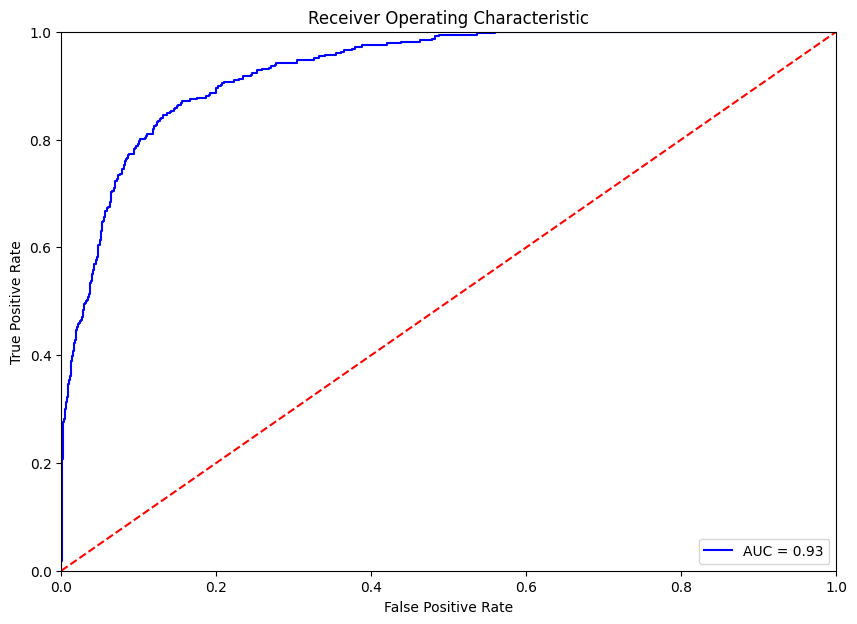

```python
# Representamos gráficamente para comprender de mejor manera la curva ROC
preds = y_test_pred_prob[:,1]
fpr, tpr, threshold = metrics.roc_curve(Y_test, preds)
roc_auc = metrics.auc(fpr, tpr)

plt.figure(figsize=(10,7))
plt.title('Receiver Operating Characteristic')
plt.plot(fpr, tpr, 'b', label = 'AUC = %0.2f' % roc_auc)
plt.legend(loc = 'lower right')
plt.plot([0, 1], [0, 1],'r--')
plt.xlim([0, 1])
plt.ylim([0, 1])
plt.ylabel('True Positive Rate')
plt.xlabel('False Positive Rate')
plt.show()
```

```python
# Calculamos las ROC AUC en función de los umbrales definidos
m_roc_auc = {}
for umbral in [0.1, 0.2, 0.3, 0.4, 0.5, 0.6]:
    y_umbralizadas = 1*(y_test_pred_prob[:, 1] > umbral)
    m_roc_auc[umbral] = metrics.roc_auc_score(Y_test, y_umbralizadas)
m_roc_auc
```

```
{0.1: 0.8466363006440041,
 0.2: 0.8477164343360235,
 0.3: 0.8321105404744437,
 0.4: 0.8004402054292004,
 0.5: 0.7633946767750875,
 0.6: 0.7265631368712807}
```

Tal como se observa, el umbral de 0.2 máximiza el área bajo la curva ROC

```python
# Calculamos las métricas accuracy, sensitividad, predición y la matriz de confusión con el umbral definido
y_umbralizadas = 1*(y_test_pred_prob[:, 1] > 0.2)
print(u"Matriz de confusión\n", metrics.confusion_matrix(Y_test, y_umbralizadas))
print("\nAccuracy\t{}".format(round(metrics.accuracy_score(Y_test, y_umbralizadas),2)))
print("Sensitividad\t{}".format(round(metrics.recall_score(Y_test, y_umbralizadas),2)))
print(u"Precisión\t{}".format(round(metrics.precision_score(Y_test, y_umbralizadas),2)))
print(u"ROC_AUC\t\t{}".format(round(metrics.roc_auc_score(Y_test, y_umbralizadas),2)))
```

```
Matriz de confusión
 [[1863  225]
 [  74  302]]

Accuracy	0.88
Sensitividad	0.8
Precisión	0.57
ROC_AUC		0.85
```

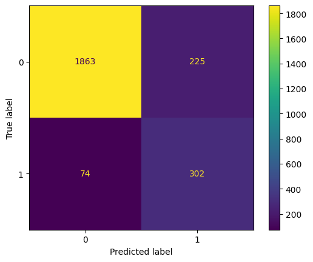

```python
#  Finalmente hacemos una representación gráfica de la matriz de confusión para facilitar su interpretación
matrix =  metrics.confusion_matrix(Y_test, y_umbralizadas)
disp = metrics.ConfusionMatrixDisplay(confusion_matrix=matrix, display_labels=modelo_XG_gs.classes_)
disp.plot()
plt.show()
```

Vemos que al maximizar la curva ROC AUC, el modelo tiene una capacidad de detectar verdaderos positivos cercana al 80%, por lo que detectaría 8 de cada 10 clientes que podrían generar ingresos al comprar en la web. No obstante, el modelo también tiende a identificar como casos positivos un porcentaje significativo de casos que realmente son negativos, considerando el total de casos identificados de forma correcta como clientes que potencialmente generarían ingresos, por lo que podría incidir en que se utilicen recursos para dar seguimiento a clientes que al final no materialicen ingresos.

En este punto es importante que la empresa considere si estas conclusiones se mantienen dentro de su apetito, respecto a la capacidad de identificación y los recursos disponibles para dar seguimiento.